[figure not shown]

# Ruby Plotting with Galaaz

An example of tightly coupling Ruby and R (JRuby or CRuby + GNU R, Galaaz 2.0)

Rodrigo Botafogo

16 October 2018 (narrative updated for Galaaz 2.0, 2026)

# 1 Introduction

Galaaz is a system for tightly coupling Ruby and R. Ruby is a powerful language, with a large community, a very large set of libraries and great for web development. However, it lacks libraries for data science, statistics, scientific plotting and machine learning. On the other hand, R is considered one of the most powerful languages for solving all of the above problems. **Python** is a strong competitor: NumPy, pandas, SciPy, and scikit-learn are widely used examples among **many thousands** of packages on PyPI for numerical and ML work.

With Galaaz we do not intend to re-implement any of the scientific libraries in R; we allow for very tight coupling between the two languages to the point that the Ruby developer does not need to think about R syntax for every call. **Galaaz 2.0** does this with **[JRuby](https://www.jruby.org/)** or **CRuby** and **GNU R**: a **bridge** evaluates R from Ruby and exchanges data between processes.

An **earlier** Galaaz prototype used Oracle’s **GraalVM** with **TruffleRuby** and **FastR** in one JVM. That stack is **historical**; today’s documentation and tooling assume **NewBridge on JRuby or CRuby** (see the project manual and **`bin/galaaz-ruby`** / **`bin/gknit`**).

For background on the old stack:

- [GraalVM Home](https://www.graalvm.org/)
- [TruffleRuby](https://github.com/oracle/truffleruby)
- [FastR](https://github.com/oracle/fastr)
- [Faster R with FastR](https://medium.com/graalvm/faster-r-with-fastr-4b8db0e0dceb)

## 1.1 What does Galaaz mean

Galaaz is the Portuguese name for “Galahad”. From Wikipedia:

```
Sir Galahad (sometimes referred to as Galeas or Galath),
in Arthurian legend, is a knight of King Arthur's Round Table and one
of the three achievers of the Holy Grail. He is the illegitimate son
of Sir Lancelot and Elaine of Corbenic, and is renowned for his
gallantry and purity as the most perfect of all knights. Emerging quite
late in the medieval Arthurian tradition, Sir Galahad first appears in the
Lancelot–Grail cycle, and his story is taken up in later works such as
the Post-Vulgate Cycle and Sir Thomas Malory's Le Morte d'Arthur.
His name should not be mistaken with Galehaut, a different knight from
Arthurian legend.
```

# 2 Galaaz Demo

## 2.1 Prerequisites (Galaaz 2.0)

- **JRuby** and a compatible **JDK**, *or* **CRuby 3.3+**
- **GNU R** on your `PATH`

The following R packages will be automatically installed when necessary, but could be installed prior to the demo if desired:

- ggplot2
- gridExtra

Installation of R packages requires a development environment. On Linux, a typical build toolchain (GCC, headers) is usually enough. On macOS, Apple’s **Xcode Command Line Tools** are commonly required.

In order to run the ‘specs’ the following Ruby package is necessary:

- gem install rspec

## 2.2 Preparation

- gem install galaaz

## 2.3 Running the demo

The ggplot examples for this demo were adapted from: http://r-statistics.co/Top50-Ggplot2-Visualizations-MasterList-R-Code.html.

At the shell, from a suitable Galaaz environment:

```
galaaz master_list:scatter_plot
```

## 2.4 Running other demos

Running

```
galaaz -T
```

lists available demo tasks. To run a demo, use **`galaaz`** where you would otherwise invoke **`rake`**. For example, if the list shows `rake sthda:bar`, run `galaaz sthda:bar`. To run every demo in the **sthda** category, use `galaaz sthda:all`. Some examples require **rspec**; install it with `gem install rspec`.

# 3 The demo code

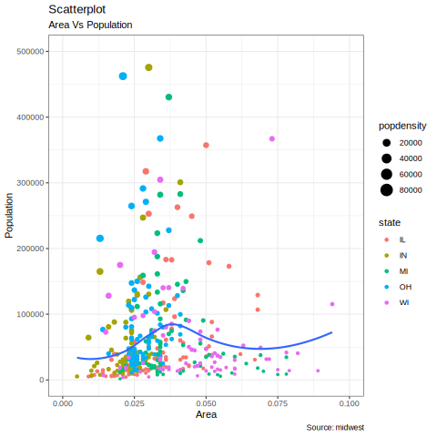

```ruby
require 'galaaz'
require 'ggplot'

# load package and data
R.options(scipen: 999)  # turn-off scientific notation like 1e+48
R.theme_set(R.theme_bw)  # pre-set the bw theme.

midwest = ~R[:midwest]

# Scatterplot
gg = midwest.ggplot(E.aes(x: :area, y: :poptotal)) +
     R.geom_point(E.aes(col: :state, size: :popdensity)) +
     R.geom_smooth(method: "loess", se: false) +
     R.xlim(R.c(0, 0.1)) +
     R.ylim(R.c(0, 500000)) +
     R.labs(subtitle: "Area Vs Population",
            y: "Population",
            x: "Area",
            title: "Scatterplot",
            caption: "Source: midwest")

puts gg
```

In R, the code to generate this plot is the following

```r
# install.packages("ggplot2")
# load package and data
options(scipen=999)  # turn-off scientific notation like 1e+48
library(ggplot2)
theme_set(theme_bw())  # pre-set the bw theme.
data("midwest", package = "ggplot2")
# midwest <- read.csv("http://goo.gl/G1K41K")  # bkup data source

# Scatterplot
gg <- ggplot(midwest, aes(x=area, y=poptotal)) +
      geom_point(aes(col=state, size=popdensity)) +
      geom_smooth(method="loess", se=F) +
      xlim(c(0, 0.1)) +
      ylim(c(0, 500000)) +
      labs(subtitle="Area Vs Population",
           y="Population",
           x="Area",
           title="Scatterplot",
           caption = "Source: midwest")

plot(gg)
```

Note that both codes are very similar. The Ruby code requires the use of “R.” before calling any functions, for instance R function ‘geom_point’ becomes ‘R.geom_point’ in Ruby. R named parameters such as (col = state, size = popdensity), become in Ruby (col: :state, size: :popdensity).

One last point that needs to be observed is the call to the ‘aes’ function. In Ruby instead of doing ‘R.aes’, we use ‘E.aes’. The explanation of why E.aes is needed is an advanced topic in R and depends on what is know as Non-standard Evaluation (NSE) in R. In short, function ‘aes’ is lazily evaluated in R, i.e., in R when calling geom_point(aes(col=state, size=popdensity)), function geom_point receives as argument something similar to a string containing ‘aes(col=state, size=popdensity)’, and the aes function will be evaluated inside the geom_point function. In Ruby, there is no Lazy evaluation and doing R.aes would try to evaluate aes immediately. In order to delay the evaluation of function aes we need to use E.aes. The interested reader on NSE in R is directed to http://adv-r.had.co.nz/Computing-on-the-language.html.

# 4 An extension to the example

If both codes are so similar, then why would one use Ruby instead of R and what good is galaaz after all?

Ruby is a modern OO language with numerous very useful constructs such as classes, modules, blocks, procs, etc. The example above focus on the coupling of both languages, and does not show the use of other Ruby constructs. In the following example, we will show a more complex example using other Ruby constructs. This is certainly not a very well written and robust Ruby code, but it give the idea of how Ruby and R are strongly coupled.

Let’s imagine that we work in a corporation that has its plot themes. So, it has defined a ‘CorpTheme’ module. Plots in this corporation should not have grids, numbers in labels should not use scientific notation and the preferred color is blue.

```ruby
# corp_theme.rb
# defines the corporate theme for all plots

module CorpTheme

  # ---------------------------------------------------------------
  # Plot theme: no major/minor grids, borders, or background;
  # turn off scientific notation.
  # ---------------------------------------------------------------

  def self.global_theme

    R.options(scipen: 999)  # turn-off scientific notation like 1e+48

    # remove major grids
    global_theme =
      R.theme(panel__grid__major: E.element_blank())
    # remove minor grids
    global_theme = global_theme +
      R.theme(panel__grid__minor: E.element_blank)
    # remove border
    global_theme = global_theme +
      R.theme(panel__border: E.element_blank)
    # remove background
    global_theme = global_theme +
      R.theme(panel__background: E.element_blank)
    # Change axis font
    global_theme = global_theme +
      R.theme(axis__text: E.element_text(
                size: 8, color: "#000080"))
    # change color of axis titles
    global_theme = global_theme +
      R.theme(axis__title: E.element_text(
                color: "#000080",
                face: "bold",
                size: 8,
                hjust: 1))
  end

end
```

We now define a ScatterPlot class:

```ruby
# ScatterPlot.rb
# creates a scatter plot and allow some configuration

class ScatterPlot

  attr_accessor :title
  attr_accessor :subtitle
  attr_accessor :caption
  attr_accessor :x_label
  attr_accessor :y_label

  # ---------------------------------------------------------------
  # Initialize the plot with the data and the x and y variables
  # ---------------------------------------------------------------

  def initialize(data, x:, y:)
    @data = data
    @x = x
    @y = y
  end

  # ---------------------------------------------------------------
  # Define groupings by color and size
  # ---------------------------------------------------------------

  def group_by(color:, size:)
    @color_by = color
    @size_by = size
  end

  # ---------------------------------------------------------------
  # Add a smoothing line; confidence: true draws a CI band.
  # ---------------------------------------------------------------

  def add_smoothing_line(method:, confidence: true)
    @method = method
    @confidence = confidence
  end

  # ---------------------------------------------------------------
  # Graph title / labels, formatted for this theme.
  # @param title [String] title to add to the graph
  # @return labs() result that can be included in a graph
  # ---------------------------------------------------------------

  def graph_params(title: "", subtitle: "", caption: "",
                   x_label: "", y_label: "")
    R.labs(
      title: title,
      subtitle: subtitle,
      caption: caption,
      y_label: y_label,
      x_label: x_label,
    )
  end

  # ---------------------------------------------------------------
  # Prepare the plot's points
  # ---------------------------------------------------------------

  def points
    params = {}
    params[:col] = @color_by if @color_by
    params[:size] = @size_by if @size_by
    R.geom_point(E.aes(params))
  end

  # ---------------------------------------------------------------
  # Plots the scatterplot
  # ---------------------------------------------------------------

  def plot
    gg = @data.ggplot(E.aes(x: @x, y: @y)) +
      points +
      R.geom_smooth(method: @method, se: @confidence) +
      R.xlim(R.c(0, 0.1)) +
      R.ylim(R.c(0, 500000)) +
      graph_params(title: @title,
                   subtitle: @subtitle,
                   y_label: @y_label,
                   x_label: @x_label,
                   caption: @caption) +
      CorpTheme.global_theme

    puts gg
  end

end
```

And this is the final code for making the scatter plot with the midwest data

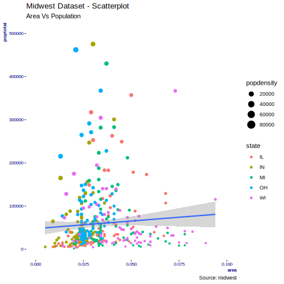

```ruby
require 'galaaz'
require 'ggplot'

sp = ScatterPlot.new(~R[:midwest], x: :area, y: :poptotal)
sp.title = "Midwest Dataset - Scatterplot"
sp.subtitle = "Area Vs Population"
sp.caption = "Source: midwest"
sp.x_label = "Area"
sp.y_label = "Population"
# try: sp.group_by(color: :state)
sp.group_by(color: :state, size: :popdensity)
# available methods: "lm", "glm", "loess", "gam"
sp.add_smoothing_line(method: "glm")
sp.plot
```

# 5 Conclusion

R is a very powerful language for statistical analysis, data analytics, machine learning, plotting and many other scientific applications with a very large package ecosystem. However R is often considered hard to learn and lacking modern language features such as object-oriented classes, modules, and first-class functions. For that reason, many teams have standardized on Python (or stayed entirely inside R) rather than mixing ecosystems.

With Galaaz, R programmers can almost transparently migrate from R to Ruby, since syntax is almost identical and **GNU R** remains the engine for statistics and **ggplot2**. Further, by using Galaaz the R developer can start (slowly if needed) using Ruby’s constructs and libraries that nicely complement R packages.

For the Ruby developer, Galaaz allows the immediate use of R functions with minimal ceremony. As shown in the second example above, class `ScatterPlot` hides most R call details from the Ruby developer. Prefer **JRuby** when you want **real parallel threads** on the Ruby side and access to the JVM ecosystem; **CRuby** works equally for the Galaaz bridge itself.